### This report shows applyining statistical tests of the results of Multi armed bandit of pruning the parameters

### "pruning the weights using TS"

### Here, we are showing two kinds of testing ANOVA test and Nonparametric tests

# Import needed libraries

## Import libraries for manipulating the data and statistic

```python
import numpy as np
import pandas as pd
import matplotlib.pyplot as plt
import scipy.stats as stats
from scipy.stats import ttest_1samp, wilcoxon, ttest_ind, mannwhitneyu
import scipy.special as special
import emoji
from math import pi
from statsmodels.stats.multicomp import pairwise_tukeyhsd, MultiComparison
from statsmodels.formula.api import ols
import statsmodels.stats.api as sms
```

## Import libraries for static ploting

```python
import matplotlib.pyplot as plt
import matplotlib.gridspec as gridspec
%matplotlib inline
from IPython.display import set_matplotlib_formats
set_matplotlib_formats('png', 'pdf')
# some nice colors from http://colorbrewer2.org/
COLOR1 = '#7fc97f'
COLOR2 = '#beaed4'
COLOR3 = '#fdc086'
COLOR4 = '#ffff99'
COLOR5 = '#386cb0'
```

## Import libraries for interactive ploting Plotly

```python
import plotly.plotly as py
from plotly.graph_objs import *
import plotly.graph_objs as go
#from plotly.tools import FigureFactory as FF
import plotly.figure_factory as FF
import cufflinks as cf
cf.go_offline()
```

## Import libraries for interactive ploting BOKEH

```python
from bokeh.charts import Bar, Area, defaults, Donut
from bokeh.layouts import row, gridplot
from bokeh.charts.attributes import cat, color
from bokeh.charts.operations import blend
from bokeh.plotting import figure, output_notebook, show
from bokeh.models import Legend
TOOLS = 'box_zoom,box_select,crosshair,resize,reset,lasso_select,pan,save,poly_select,tap,wheel_zoom,undo'
#defaults.width = 1000
#defaults.height = 800
output_notebook()
```

# Statring the test and visulize the data

## Load the data for pruning the weights using random expoloration

```python
datafile = "TS.csv"
datafileLeNet = "LecunPruningWeights.csv"
df1 = pd.read_csv(datafile)
dfLcun = pd.read_csv(datafileLeNet)
df1
```

|  | Dataset | Model | Thom. Sam | OBD | OBS | Magnitude | random |
| --- | --- | --- | --- | --- | --- | --- | --- |
| 0 | banknote authentication | 0.01 | 0.01 | 0.01 | 0.02 | 3.23 | 5.13 |
| 1 | Blood Tra. Service Centre | 0.08 | 0.08 | 0.08 | 0.08 | 0.44 | 0.08 |
| 2 | Credit Approval | 0.08 | 0.78 | 0.08 | 8.62 | 2.55 | 22.19 |
| 3 | Haberman's Survival | 0.09 | 0.08 | 0.08 | 0.08 | 0.63 | 0.65 |
| 4 | Liver Disorders | 0.10 | 0.10 | 0.10 | 0.85 | 0.62 | 0.15 |
| 5 | MAGIC Gamma Tele. | 0.06 | 0.06 | 0.06 | 0.12 | 2.49 | 0.43 |
| 6 | Mammographic Mass | 0.09 | 0.09 | 0.09 | 0.09 | 2.59 | 0.13 |
| 7 | MONK's Problems | 0.10 | 0.10 | 0.10 | 5.28 | 0.15 | 0.13 |
| 8 | Connectionist Bench | 0.12 | 1.07 | 0.12 | 0.12 | 0.16 | 0.16 |
| 9 | Spambase | 0.08 | 0.09 | 0.08 | 4.37 | 1.67 | 5.01 |
| 10 | SPECTF Heart | 0.06 | 0.08 | 0.06 | 0.14 | 12.25 | 0.06 |
| 11 | Tic-Tac-Toe Endgame | 0.06 | 0.06 | 0.06 | 0.07 | 21.30 | 11.92 |

```python
dfLcun
```

|  | Layer | Model | TS Prune half the weights |
| --- | --- | --- | --- |
| 0 | FC | 0.9906 | 0.993 |
| 1 | Conv | 0.9906 | 0.991 |

```python
p = Bar(df1, label='Dataset',
        values = blend('Model', 'Thom. Sam' ,'OBD','OBS',
                       'Magnitude',
                       'random',name='Scores', labels_name='Score'),
       group=cat(columns='Score', sort=False),
       title="Compare the performance", legend='top_center',
       tools=TOOLS, plot_width=900, plot_height=600,
       tooltips=[('Score', '@Score'), ('Model', '@Dataset')],
       xlabel='List of datasets', ylabel='Error')
p.title.align = "center"
#p.yaxis.major_label_orientation = "vertical"
p.xaxis.major_label_orientation = pi/2
show(p)
```

[interactive chart not shown]

```python
p = Bar(dfLcun, label='Layer',
        values = blend('Model', 'TS Prune half the weights',name='Scores', labels_name='Score'),
       group=cat(columns='Score', sort=False),
       title="Compare the performance", legend='bottom_center',
       tools=TOOLS, plot_width=900, plot_height=600,
       tooltips=[('Score', '@Score'), ('Model', '@Layer')],
       xlabel='List of Layers', ylabel='Accuracy')
p.title.align = "center"
#p.yaxis.major_label_orientation = "vertical"
p.xaxis.major_label_orientation = pi/2
show(p)
```

[interactive chart not shown]

```python
df=df1.copy()
df.set_index('Dataset', inplace=True)
py.iplot([{
    'x': df.index,
    'y': df[col],
    'name': col
}  for col in df.columns])
```

[interactive chart not shown]

```python
# Lecun Model
dflc=dfLcun.copy()
dflc.set_index('Layer', inplace=True)
py.iplot([{
    'x': dflc.index,
    'y': dflc[col],
    'name': col
}  for col in dflc.columns])
```

[interactive chart not shown]

```python
df.iplot(subplots=True, subplot_titles=True, legend=False )
```

[interactive chart not shown]

```python
df.iplot(subplots=True, shape=(8,1), shared_xaxes=True, fill=True)
```

[interactive chart not shown]

```python
df.iplot(kind='bar')
```

[interactive chart not shown]

```python
df.iplot(kind='bar', barmode='stack')
```

[interactive chart not shown]

```python
df.iplot(kind='barh',barmode='stack', bargap=.2)
```

[interactive chart not shown]

```python
df.iplot(kind='histogram')
```

[interactive chart not shown]

```python
df.scatter_matrix(world_readable=True)
```

[interactive chart not shown]

```python
df.iplot(kind='box')
```

[interactive chart not shown]

```python
p = Bar(df1, label='Dataset',
        values = blend('Model', 'Thom. Sam',name='Scores', labels_name='Score'),
       group=cat(columns='Score', sort=False),
       title="Compare the performance", legend='top_center',
       tools=TOOLS, plot_width=900, plot_height=600,
       tooltips=[('Score', '@Score'), ('Model', '@Dataset')],
       xlabel='List of datasets', ylabel='Error')
p.title.align = "center"
#p.yaxis.major_label_orientation = "vertical"
p.xaxis.major_label_orientation = pi/2
#################################################################################
show(p)
```

[interactive chart not shown]

### We will use alpha 0.05 to do ANOVA test. The null hypothesis there is no difference between the all methods and the alternative hypothesis there is a difference. According to p-value we see if there is a difference.

```python
# Perform the ANOVA
stats.f_oneway(df1['Model'],df1['Thom. Sam'] , df1['OBD'],
               df1['OBS'],df1['Magnitude'],df1['random'])
```

```
F_onewayResult(statistic=2.6273655974573149, pvalue=0.031563475049194982)
```

The test result suggests the groups don't have the same sample means in this case, since the p-value is significant at a 95% confidence level.

We want to test the best pruning model which is this case is TS family

To check which groups differ after getting a positive ANOVA result, we can perform a follow up test or "post-hoc test".

### One post-hoc test is to perform a separate t-test for each pair of groups. We can perform a t-test between all pairs using by running each pair through the stats.ttest_ind() we covered in the following to do t-tests:

```python
# Get all models pairs
interstModel = ['Thom. Sam']
lst = list(df1.columns.values)
lst.remove('Dataset')
model_pairs = []

for m1 in range(len(df1.columns)-2):
    for m2  in range(m1+1,len(df1.columns)-1):
        model_pairs.append((lst[m1], lst[m2]))

# Conduct t-test on each pair
pvalueList = []
new_model_pairs = []
for m1, m2 in model_pairs:
    print('\n',m1, m2)
    pvalue = stats.ttest_ind(df1[m1], df1[m2])
    #print(pvalue[1])
    if (m1 in interstModel or m2 in interstModel):
        new_model_pairs.append((m1,m2))
        pvalueList.append(pvalue[1])
    print(pvalue)
```

```
 Model Thom. Sam
Ttest_indResult(statistic=-1.4236866987486101, pvalue=0.16856608350251728)

 Model OBD
Ttest_indResult(statistic=0.073234127598741677, pvalue=0.94228157972204629)

 Model OBS
Ttest_indResult(statistic=-1.9160734438661973, pvalue=0.068440210215287733)

 Model Magnitude
Ttest_indResult(statistic=-2.1405072319282352, pvalue=0.043650582535484338)

 Model random
Ttest_indResult(statistic=-1.9125261657982566, pvalue=0.068916013437619064)

 Thom. Sam OBD
Ttest_indResult(statistic=1.4323016719620232, pvalue=0.16611391988577526)

 Thom. Sam OBS
Ttest_indResult(statistic=-1.7348147949885926, pvalue=0.096763985488854717)

 Thom. Sam Magnitude
Ttest_indResult(statistic=-2.0618114351977597, pvalue=0.051234112020019824)

 Thom. Sam random
Ttest_indResult(statistic=-1.8394809707113433, pvalue=0.079379195796686619)

 OBD OBS
Ttest_indResult(statistic=-1.9170884030883408, pvalue=0.068304603881402803)

 OBD Magnitude
Ttest_indResult(statistic=-2.140961591206707, pvalue=0.043609903648211962)

 OBD random
Ttest_indResult(statistic=-1.9129504322071127, pvalue=0.068858953230263545)

 OBS Magnitude
Ttest_indResult(statistic=-1.1699913498827907, pvalue=0.254523709674912)

 OBS random
Ttest_indResult(statistic=-1.0247290048069007, pvalue=0.3166273271391854)

 Magnitude random
Ttest_indResult(statistic=0.063211556114818712, pvalue=0.95016886148726365)
```

```python
for pair, p in zip(new_model_pairs, pvalueList):
    if p < 0.05:
        print('The pvalue between',pair, 'is', p, '< 0.05 then',
              emoji.emojize('REJECT the NULL Hypothesis :thumbs_up_sign:'))
    else:
        print('The pvalue between',pair, 'is', p, '> 0.05 then',
              emoji.emojize('FAIL to REJECT the NULL Hypothesis :thumbs_down_sign:'))
```

```
The pvalue between ('Model', 'Thom. Sam') is 0.168566083503 > 0.05 then FAIL to REJECT the NULL Hypothesis 👎
The pvalue between ('Thom. Sam', 'OBD') is 0.166113919886 > 0.05 then FAIL to REJECT the NULL Hypothesis 👎
The pvalue between ('Thom. Sam', 'OBS') is 0.0967639854889 > 0.05 then FAIL to REJECT the NULL Hypothesis 👎
The pvalue between ('Thom. Sam', 'Magnitude') is 0.05123411202 > 0.05 then FAIL to REJECT the NULL Hypothesis 👎
The pvalue between ('Thom. Sam', 'random') is 0.0793791957967 > 0.05 then FAIL to REJECT the NULL Hypothesis 👎
```

```python
matrix_twosample = []
matrix_twosample.append(['Methods', 'P value', 'Null Hypothesis', 'EMOJI'])
for pair, p in zip(new_model_pairs, pvalueList):
    if p < 0.05:
        matrix_twosample.append((pair, p, 'REJECT', emoji.emojize(':thumbs_up_sign:')))
    else:
        matrix_twosample.append((pair, p, 'ACCEPT (FAIL TO REJECT)', emoji.emojize(':thumbs_down_sign:')))
colorscale = [[0, '#4d004c'],[.5, '#f2e5ff'],[1, '#ffffff']]
#colorscale = [[0, '#272D31'],[.5, '#ffffff'],[1, '#ffffff']]
#font=['#FCFCFC', '#00EE00', '#008B00', '#004F00', '#660000', '#CD0000', '#FF3030']
#font=['#FCFCFC', '#00EE00', '#008B00']
#table.layout.width=250
twosample_table = FF.create_table(matrix_twosample, index=True, colorscale=colorscale)
py.iplot(twosample_table)
```

[interactive chart not shown]

### Margin of Error and Confidence Intervals

margin of error = Tcritical*SE

Confidence Intervals = point estimate ± Margin of Error

#### 1. For TS

```python
dd = df1.copy()
dd['diff'] = dd['Thom. Sam'] - dd['Model']
n = len(dd['diff'])
t = stats.t.ppf(1-0.025, n)
def interval_margin(d, t):
    mn = d.mean()
    sd = d.std()
    se = sd/np.sqrt(len(d))
    m = se * t
    ci_lower = mn - m
    ci_upper = mn + m
    return mn, ci_lower, ci_upper, m

Pint_Estimate, Lower_CI, Upper_CI, Margin_of_Error = interval_margin(dd['diff'], t)
print('Point Estimate =', Pint_Estimate )
print('\nMargin of Error =', Margin_of_Error )
print('\nConfidence Intervals = point estimate ± Margin of Error')
print('Confidence Intervals = ', Pint_Estimate, '±', Margin_of_Error)
print('Confidence Intervals = (', Lower_CI,',', Upper_CI, ')' )
```

```
Point Estimate = 0.139166666667

Margin of Error = 0.204310831595

Confidence Intervals = point estimate ± Margin of Error
Confidence Intervals =  0.139166666667 ± 0.204310831595
Confidence Intervals = ( -0.065144164928 , 0.343477498261 )
```

## Perform Tukey's range test (Tukey's Honestly Significant Difference)

Create a set of confidence intervals on the differences between the means of the levels of a factor with the specified family-wise probability of coverage. The intervals are based on the Studentized range statistic, Tukey's ‘Honest Significant Difference’ method. [Wekipedia]

```python
df_for_Tukey = df1.copy()
del df_for_Tukey['Dataset']
```

```python
# group the data as tukeyhsd is needed
lst = []
for c in df_for_Tukey.columns:
    for r in df_for_Tukey[c]:
        lst.append((c,r))
```

```python
# make two groups
data = np.rec.array(lst,
                    dtype = [('Model','|U10'),('Score', '<f2')])
```

```python
# perform the test
mc = MultiComparison(data['Score'], data['Model'])
result = mc.tukeyhsd()
print(result)
```

```
Multiple Comparison of Means - Tukey HSD,FWER=0.05
==================================================
  group1    group2  meandiff  lower  upper  reject
--------------------------------------------------
Magnitude   Model    -3.929   -8.697 0.839  False
Magnitude    OBD    -3.9298  -8.6978 0.8381 False
Magnitude    OBS    -2.3532  -7.1212 2.4148 False
Magnitude Thom. Sam -3.7898  -8.5578 0.9781 False
Magnitude   random  -0.1699  -4.9378 4.5981 False
  Model      OBD    -0.0008  -4.7688 4.7671 False
  Model      OBS     1.5758  -3.1922 6.3438 False
  Model   Thom. Sam  0.1392  -4.6288 4.9071 False
  Model     random   3.7592  -1.0088 8.5271 False
   OBD       OBS     1.5766  -3.1913 6.3446 False
   OBD    Thom. Sam   0.14    -4.628 4.908  False
   OBD      random    3.76    -1.008 8.528  False
   OBS    Thom. Sam -1.4366  -6.2046 3.3313 False
   OBS      random   2.1834  -2.5846 6.9513 False
Thom. Sam   random    3.62    -1.148 8.3879 False
--------------------------------------------------
```

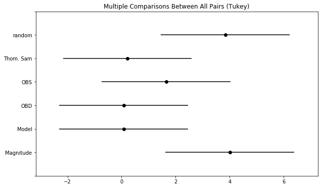

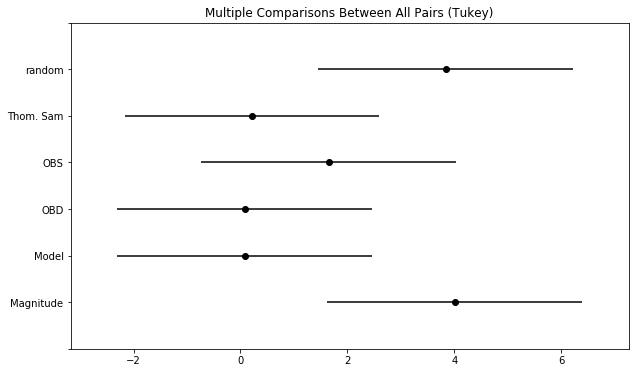

```python
result.plot_simultaneous()
```

## eta squared

proportion of total variation that is due to between group differences (explain variation)

http://imaging.mrc-cbu.cam.ac.uk/statswiki/FAQ/effectSize

```python
def FPvalue( *args):

    df_btwn, df_within = __degree_of_freedom_( *args)

    mss_btwn = __ss_between_( *args) / float( df_btwn)
    mss_within = __ss_within_( *args) / float( df_within)

    F = mss_btwn / mss_within
    P = special.fdtrc( df_btwn, df_within, F)

    return( F, P)

def EtaSquare( *args):

    return( float( __ss_between_( *args) / __ss_total_( *args)))

def __concentrate_( *args):

    v = list( map( np.asarray, args))
    vec = np.hstack( np.concatenate( v))
    return( vec)

def __ss_total_( *args):

    vec = __concentrate_( *args)
    ss_total = sum( (vec - np.mean( vec)) **2)
    return( ss_total)

def __ss_between_( *args):

    grand_mean = np.mean( __concentrate_( *args))

    ss_btwn = 0
    for a in args:
        ss_btwn += ( len(a) * ( np.mean( a) - grand_mean) **2)

    return( ss_btwn)

def __ss_within_( *args):
    return( __ss_total_( *args) - __ss_between_( *args))

def __degree_of_freedom_( *args):
    args = list( map( np.asarray, args))
    # number of groups minus 1
    df_btwn = len( args) - 1

    # total number of samples minus number of groups
    df_within = len( __concentrate_( *args)) - df_btwn - 1

    return( df_btwn, df_within)
eta = EtaSquare(df1['OBS'], df1['Model'],df1['OBD'],
                df1['Thom. Sam'], df1['Magnitude'])
print('The Eta square of anova test is ', eta)
if eta>=0.14:
    print('This eta square consider to be Large')
elif 0.06<=eta<0.14:
    print('This eta square consider to be Medium')
elif 0.01<=eta<0.06:
    print('This eta square consider to be Small')
else:
    print('This eta square consider to be very Small')
```

```
The Eta square of anova test is  0.20596923876279902
This eta square consider to be Large
```

## Cohen's d

if any two samples have a bsolute different greater that 2.505 the the different conseder honestly significant difference

```python
# Compute Cohen's d
from numpy import std, mean, sqrt
def cohen_d(x,y):
    if type(x)==list: # if the input data list
        nx = len(x)
        ny = len(y)
        dof = nx + ny - 2
        return (mean(x) - mean(y)) / sqrt(((nx-1)*std(x, ddof=1) ** 2 + (ny-1)*std(y, ddof=1) ** 2) / dof)
    else:   # if the input numpy array or series[pandas]
        diff = x.mean() - y.mean()
        n1, n2 = len(x), len(y)
        var1 = x.var()
        var2 = y.var()
        pooled_var = (n1 * var1 + n2 * var2) / (n1 + n2)
        return (diff / np.sqrt(pooled_var))
```

```python
def eval_pdf(rv, num=4):
    mean, std = rv.mean(), rv.std()
    xs = np.linspace(mean - num*std, mean + num*std, 100)
    ys = rv.pdf(xs)
    return xs, ys
```

```python
def overlap_superiority(control, treatment, n=1000):
    control_sample = control.rvs(n)
    treatment_sample = treatment.rvs(n)
    thresh = (control.mean() + treatment.mean()) / 2

    control_above = sum(control_sample > thresh)
    treatment_below = sum(treatment_sample < thresh)
    overlap = (control_above + treatment_below) / n

    superiority = sum(x > y for x, y in zip(treatment_sample, control_sample)) / n
    return overlap, superiority
```

```python
def plot_pdfs(cohen_d=2):
    control = stats.norm(0, 1)
    treatment = stats.norm(cohen_d, 1)
    xs, ys = eval_pdf(control)
    plt.fill_between(xs, ys, label='control', color=COLOR3, alpha=0.7)

    xs, ys = eval_pdf(treatment)
    plt.fill_between(xs, ys, label='treatment', color=COLOR2, alpha=0.7)

    o, s = overlap_superiority(control, treatment)
    print('overlap', o)
    print('superiority', s)
```

```
The Cohen d between TS and Model is 0.58121766092 <2.505 then No honestly significant difference 👎
overlap 0.776
superiority 0.655
```

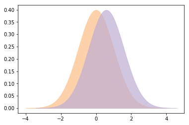

```python
c2 = cohen_d(df1['Thom. Sam'], df1['Model'])
if c2 >= 2.505:
    print('The Cohen d between TS and Model is', c2, '>2.505 then',
          emoji.emojize('honestly significant differences :thumbs_up_sign:'))
else:
    print('The Cohen d between TS and Model is', c2, '<2.505 then',
          emoji.emojize('No honestly significant difference :thumbs_down_sign:'))
plot_pdfs(c2)
```

## t student test in Lecun Model

```python
dfLcun
```

|  | Layer | Model | TS Prune half the weights |
| --- | --- | --- | --- |
| 0 | FC | 0.9906 | 0.993 |
| 1 | Conv | 0.9906 | 0.991 |

```python
print('TS vs random Pruning')
H, pval = stats.ttest_ind(dfLcun['TS Prune half the weights'], dfLcun['Model'])
print ("H-statistic:\t%s\nP-value:\t%s" % (str(H),str(pval/2)))
if pval/2 < 0.05:
    print("Reject NULL hypothesis - Significant differences exist between groups.")
if pval/2 > 0.05:
    print("Accept NULL hypothesis - No significant difference between groups.")
```

```
TS vs random Pruning
H-statistic:	1.4
P-value:	0.148236764659
Accept NULL hypothesis - No significant difference between groups.
```

```
The Cohen d between TS and Model is 1.4 <2.505 then No honestly significant difference 👎
overlap 0.49
superiority 0.829
```

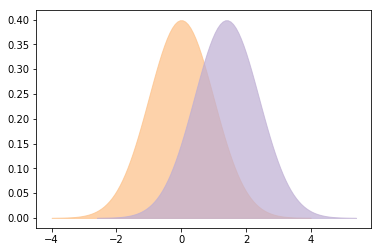

```python
cL = cohen_d(dfLcun['TS Prune half the weights'], dfLcun['Model'])
if cL >= 2.505:
    print('The Cohen d between TS and Model is', cL, '>2.505 then',
          emoji.emojize('honestly significant difference :thumbs_up_sign:'))
else:
    print('The Cohen d between TS and Model is', cL, '<2.505 then',
          emoji.emojize('No honestly significant difference :thumbs_down_sign:'))
plot_pdfs(cL)
```

### Margin of Error and Confidence Intervals of Lecun Model

margin of error = Tcritical*SE

Confidence Intervals = point estimate ± Margin of Error

```python
dd = dfLcun.copy()
dd['diff'] = dd['TS Prune half the weights'] - dd['Model']
n = len(dd['diff'])
t = stats.t.ppf(1-0.025, n)
def interval_margin(d, t):
    mn = d.mean()
    sd = d.std()
    se = sd/np.sqrt(len(d))
    m = se * t
    ci_lower = mn - m
    ci_upper = mn + m
    return mn, ci_lower, ci_upper, m

Pint_Estimate, Lower_CI, Upper_CI, Margin_of_Error = interval_margin(dd['diff'], t)
print('Point Estimate =', Pint_Estimate )
print('\nMargin of Error =', Margin_of_Error )
print('\nConfidence Intervals = point estimate ± Margin of Error')
print('Confidence Intervals = ', Pint_Estimate, '±', Margin_of_Error)
print('Confidence Intervals = (', Lower_CI,',', Upper_CI, ')' )
```

```
Point Estimate = 0.0014

Margin of Error = 0.00430265272991

Confidence Intervals = point estimate ± Margin of Error
Confidence Intervals =  0.0014 ± 0.00430265272991
Confidence Intervals = ( -0.00290265272991 , 0.00570265272991 )
```

# Second Ranking the elements

```python
df_copy = df1.copy()
#del df_copy['Dataset']
#df_ranked = df_copy.rank(ascending=0, axis=1, method='min')
df_ranked = df_copy.rank(ascending=0, axis=1)
df_ranked_coumt = df_ranked.copy()
df_ranked['Dataset'] = df1['Dataset']
# ranked table
df_ranked
```

|  | Model | Thom. Sam | OBD | OBS | Magnitude | random | Dataset |
| --- | --- | --- | --- | --- | --- | --- | --- |
| 0 | 5.0 | 5.0 | 5.0 | 3.0 | 2.0 | 1.0 | banknote authentication |
| 1 | 4.0 | 4.0 | 4.0 | 4.0 | 1.0 | 4.0 | Blood Tra. Service Centre |
| 2 | 5.5 | 4.0 | 5.5 | 2.0 | 3.0 | 1.0 | Credit Approval |
| 3 | 3.0 | 5.0 | 5.0 | 5.0 | 2.0 | 1.0 | Haberman's Survival |
| 4 | 5.0 | 5.0 | 5.0 | 1.0 | 2.0 | 3.0 | Liver Disorders |
| 5 | 5.0 | 5.0 | 5.0 | 3.0 | 1.0 | 2.0 | MAGIC Gamma Tele. |
| 6 | 4.5 | 4.5 | 4.5 | 4.5 | 1.0 | 2.0 | Mammographic Mass |
| 7 | 5.0 | 5.0 | 5.0 | 1.0 | 2.0 | 3.0 | MONK's Problems |
| 8 | 5.0 | 1.0 | 5.0 | 5.0 | 2.5 | 2.5 | Connectionist Bench |
| 9 | 5.5 | 4.0 | 5.5 | 2.0 | 3.0 | 1.0 | Spambase |
| 10 | 5.0 | 3.0 | 5.0 | 2.0 | 1.0 | 5.0 | SPECTF Heart |
| 11 | 5.0 | 5.0 | 5.0 | 3.0 | 1.0 | 2.0 | Tic-Tac-Toe Endgame |

```python
dfLcun
dfLcun_copy = dfLcun.copy()
#del df_copy['Dataset']
#df_ranked = df_copy.rank(ascending=0, axis=1, method='min')
dfLcun_ranked = dfLcun_copy.rank(ascending=1, axis=1)
dfLcun_ranked_coumt = dfLcun_ranked.copy()
dfLcun_ranked['Layer'] = dfLcun['Layer']
# ranked table
dfLcun_ranked.head()
```

|  | Model | TS Prune half the weights | Layer |
| --- | --- | --- | --- |
| 0 | 1.0 | 2.0 | FC |
| 1 | 1.0 | 2.0 | Conv |

```python
# old table
df1.head()
```

|  | Dataset | Model | Thom. Sam | OBD | OBS | Magnitude | random |
| --- | --- | --- | --- | --- | --- | --- | --- |
| 0 | banknote authentication | 0.01 | 0.01 | 0.01 | 0.02 | 3.23 | 5.13 |
| 1 | Blood Tra. Service Centre | 0.08 | 0.08 | 0.08 | 0.08 | 0.44 | 0.08 |
| 2 | Credit Approval | 0.08 | 0.78 | 0.08 | 8.62 | 2.55 | 22.19 |
| 3 | Haberman's Survival | 0.09 | 0.08 | 0.08 | 0.08 | 0.63 | 0.65 |
| 4 | Liver Disorders | 0.10 | 0.10 | 0.10 | 0.85 | 0.62 | 0.15 |

```python
df_ranked_coumtS = df_ranked_coumt.sum()
dfLcun_ranked_coumtS = dfLcun_ranked_coumt.sum()
```

```python
pie_chart = Donut(df_ranked_coumtS, tools=TOOLS )
pieLcun_chart = Donut(dfLcun_ranked_coumtS, tools=TOOLS )
print('On classification dataswt')
show(pie_chart)
print('On Lecun model')
show(pieLcun_chart)
```

```
On classification dataswt
```

[interactive chart not shown]

```
On Lecun model
```

[interactive chart not shown]

```python
labels = df_ranked_coumtS.index.tolist()
values =   df_ranked_coumtS.tolist()
trace=go.Pie(labels=labels,values=values)
py.iplot([trace])
```

[interactive chart not shown]

```python
labelsLcun = dfLcun_ranked_coumtS.index.tolist()
valuesLcun =   dfLcun_ranked_coumtS.tolist()
traceLcun=go.Pie(labels=labelsLcun,values=valuesLcun)
py.iplot([traceLcun])
```

[interactive chart not shown]

```python
p = Bar(df_ranked, label='Dataset',
        values = blend('Model', 'Thom. Sam', 'BayTS', 'KLTS' , 'OBD','OBS',
                       'Magnitude',
                       'random',name='Scores', labels_name='Score'),
       group=cat(columns='Score', sort=False),
       title="Compare the performance", legend='bottom_center',
       tools=TOOLS, plot_width=900, plot_height=1600,
       tooltips=[('Score', '@Score'), ('Model', '@Dataset')],
       xlabel='List of datasets', ylabel='Ranked')
p.title.align = "center"
#p.yaxis.major_label_orientation = "vertical"
p.xaxis.major_label_orientation = pi/2
show(p)
```

[interactive chart not shown]

```python
p = Bar(df_ranked, label='Dataset',
        values = blend('Model', 'Thom. Sam', name='Scores', labels_name='Score'),
       group=cat(columns='Score', sort=False),
       title="Compare the performance", legend='bottom_center',
       tools=TOOLS, plot_width=900, plot_height=600,
       tooltips=[('Score', '@Score'), ('Model', '@Dataset')],
       xlabel='List of datasets', ylabel='Ranked')
p.title.align = "center"
#p.yaxis.major_label_orientation = "vertical"
p.xaxis.major_label_orientation = pi/2
#################################################################################
show(p)
```

[interactive chart not shown]

```python
p = Bar(dfLcun_ranked, label='Layer',
        values = blend('Model', 'TS Prune half the weights',name='Scores', labels_name='Score'),
       group=cat(columns='Score', sort=False),
       title="Compare the performance", legend='bottom_center',
       tools=TOOLS, plot_width=900, plot_height=600,
       tooltips=[('Score', '@Score'), ('Model', '@Layer')],
       xlabel='List of Layers', ylabel='Ranked')
p.title.align = "center"
#p.yaxis.major_label_orientation = "vertical"
p.xaxis.major_label_orientation = pi/2
#################################################################################
show(p)
```

[interactive chart not shown]

```python
df1 = df_ranked.copy()
df=df1.copy()
df.set_index('Dataset', inplace=True)
py.iplot([{
    'x': df.index,
    'y': df[col],
    'name': col
}  for col in df.columns])
```

[interactive chart not shown]

```python
df.iplot(subplots=True, subplot_titles=True, legend=False )
```

[interactive chart not shown]

```python
df.iplot(kind='bar', barmode='stack')
```

[interactive chart not shown]

```python
df.iplot(kind='barh',barmode='stack', bargap=.2)
```

[interactive chart not shown]

```python
df.iplot(kind='box')
```

[interactive chart not shown]

## Using Nonparametric tests

I am not sure the data comes from Guassian distribution and less than 30 sample

### alternative to paired t-test when data has an ordinary scale or when not

## Start comparining all pruning algorithms

The Kruskal–Wallis test by ranks, Kruskal–Wallis H test (named after William Kruskal and W. Allen Wallis), or One-way ANOVA on ranks is a non-parametric method for testing whether samples originate from the same distribution. It is used for comparing two or more independent samples of equal or different sample sizes. It extends the Mann–Whitney U test when there are more than two groups. The parametric equivalent of the Kruskal-Wallis test is the one-way analysis of variance (ANOVA). A significant Kruskal-Wallis test indicates that at least one sample stochastically dominates one other sample. The test does not identify where this stochastic dominance occurs or for how many pairs of groups stochastic dominance obtains. Dunn's test,or the more powerful but less well known Conover-Iman test would help analyze the specific sample pairs for stochastic dominance in post hoc tests.

Since it is a non-parametric method, the Kruskal–Wallis test does not assume a normal distribution of the residuals, unlike the analogous one-way analysis of variance. If the researcher can make the less stringent assumptions of an identically shaped and scaled distribution for all groups, except for any difference in medians, then the null hypothesis is that the medians of all groups are equal, and the alternative hypothesis is that at least one population median of one group is different from the population median of at least one other group. [Wekipedia]

### Compute Kruskal–Wallis test by ranks between pruning methods

```python
from scipy.stats import mstats
H, pval = mstats.kruskalwallis(df1['Thom. Sam'], df1['OBD'], df1['OBS'],
                               df1['Magnitude'], df1['random'])
print("H-statistic:", H)
print("P-Value:", pval)
if pval < 0.05:
    print("Reject NULL hypothesis - Significant differences exist between groups.")
if pval > 0.05:
    print("Accept NULL hypothesis - No significant difference between groups.")
```

```
H-statistic: 32.7883885388
P-Value: 1.31976379369e-06
Reject NULL hypothesis - Significant differences exist between groups.
```

### Compute Kruskal–Wallis test by ranks between pruning methods including the model itself

```python
df_copy = df1.copy()
del df_copy['Dataset']
H, pval = mstats.kruskalwallis([df_copy[col] for col in df_copy.columns])
print ("H-statistic:\t%s\nP-value:\t%s" % (str(H),str(pval)))
if pval < 0.05:
    print("Reject NULL hypothesis - Significant differences exist between groups.")
if pval > 0.05:
    print("Accept NULL hypothesis - No significant difference between groups.")
```

```
H-statistic:	42.5703807161
P-value:	4.51513609877e-08
Reject NULL hypothesis - Significant differences exist between groups.
```

### is a difference between the methods

## Between our method and other methods separately as both are independent

#### First method is used if Two Independent Samples,, the population is same, To test both location and shape, and samples greater than 20

In statistics, the Mann–Whitney U test (also called the Mann–Whitney–Wilcoxon (MWW), Wilcoxon rank-sum test, or Wilcoxon–Mann–Whitney test) is a nonparametric test of the null hypothesis that it is equally likely that a randomly selected value from one sample will be less than or greater than a randomly selected value from a second sample.

Unlike the t-test it does not require the assumption of normal distributions. It is nearly as efficient as the t-test on normal distributions. [Wekipedia]

#### First method is used if Two Independent Samples,, the population is same and To test any kind of sample in the distribution

In statistics, the Kolmogorov–Smirnov test (K–S test or KS test) is a nonparametric test of the equality of continuous, one-dimensional probability distributions that can be used to compare a sample with a reference probability distribution (one-sample K–S test), or to compare two samples (two-sample K–S test). The Kolmogorov–Smirnov statistic quantifies a distance between the empirical distribution function of the sample and the cumulative distribution function of the reference distribution, or between the empirical distribution functions of two samples. The null distribution of this statistic is calculated under the null hypothesis that the sample is drawn from the reference distribution (in the one-sample case) or that the samples are drawn from the same distribution (in the two-sample case). In each case, the distributions considered under the null hypothesis are continuous distributions but are otherwise unrestricted. [Wekipedia]

### Number of samples less than 20, we will use second method

## Kolmogorov–Smirnov test between TS and other pruning methods.

## Kolmogorov-Smirnov test for goodness of fit.

## Computes the Kolmogorov-Smirnov statistic on 2 samples.

https://docs.scipy.org/doc/scipy-0.14.0/reference/generated/scipy.stats.ks_2samp.html

```python
print('TS vs random Pruning')
H, pval = stats.ks_2samp(df1['Thom. Sam'], df1['random'])
print ("H-statistic:\t%s\nP-value:\t%s" % (str(H),str(pval)))
if pval < 0.05:
    print("Reject NULL hypothesis - Significant differences exist between groups.")
if pval > 0.05:
    print("Accept NULL hypothesis - No significant difference between groups.")
```

```
TS vs random Pruning
H-statistic:	0.666666666667
P-value:	0.00459644384608
Reject NULL hypothesis - Significant differences exist between groups.
```

```python
print('TS vs Optimal Brain Damage')
H, pval = stats.ks_2samp(df1['Thom. Sam'], df1['OBD'])
print ("H-statistic:\t%s\nP-value:\t%s" % (str(H),str(pval)))
if pval < 0.05:
    print("Reject NULL hypothesis - Significant differences exist between groups.")
if pval > 0.05:
    print("Accept NULL hypothesis - No significant difference between groups.")
```

```
TS vs Optimal Brain Damage
H-statistic:	0.333333333333
P-value:	0.43330893681
Accept NULL hypothesis - No significant difference between groups.
```

```python
print('TS vs Optimal Brain Surgeon')
H, pval = stats.ks_2samp(df1['Thom. Sam'], df1['OBS'])
print ("H-statistic:\t%s\nP-value:\t%s" % (str(H),str(pval)))
if pval < 0.05:
    print("Reject NULL hypothesis - Significant differences exist between groups.")
if pval > 0.05:
    print("Accept NULL hypothesis - No significant difference between groups.")
```

```
TS vs Optimal Brain Surgeon
H-statistic:	0.5
P-value:	0.0655839639188
Accept NULL hypothesis - No significant difference between groups.
```

```python
print('TS vs Deep Compression')
H, pval = stats.ks_2samp(df1['Thom. Sam'], df1['Magnitude'])
print ("H-statistic:\t%s\nP-value:\t%s" % (str(H),str(pval)))
if pval < 0.05:
    print("Reject NULL hypothesis - Significant differences exist between groups.")
if pval > 0.05:
    print("Accept NULL hypothesis - No significant difference between groups.")
```

```
TS vs Deep Compression
H-statistic:	0.833333333333
P-value:	0.000150731821127
Reject NULL hypothesis - Significant differences exist between groups.
```

```python
# Get all models pairs
interstModel = ['Thom. Sam']
lst = list(df1.columns.values)
lst.remove('Dataset')
model_pairs = []

for m1 in range(len(df1.columns)-2):
    for m2  in range(m1+1,len(df1.columns)-1):
        model_pairs.append((lst[m1], lst[m2]))

pvalueList = []
new_model_pairs = []
for m1, m2 in model_pairs:
    print('\n',m1, m2)
    pvalue = stats.ks_2samp(df1[m1], df1[m2])
    #print(pvalue[1])
    if (m1 in interstModel or m2 in interstModel):
        new_model_pairs.append((m1,m2))
        pvalueList.append(pvalue[1])
    print(pvalue)
```

```
 Model Thom. Sam
Ks_2sampResult(statistic=0.25, pvalue=0.78641716217514468)

 Model OBD
Ks_2sampResult(statistic=0.083333333333333343, pvalue=0.99999999994070876)

 Model OBS
Ks_2sampResult(statistic=0.58333333333333337, pvalue=0.019091732631329447)

 Model Magnitude
Ks_2sampResult(statistic=0.91666666666666663, pvalue=2.0531074831625211e-05)

 Model random
Ks_2sampResult(statistic=0.75, pvalue=0.00091525414760188016)

 Thom. Sam OBD
Ks_2sampResult(statistic=0.33333333333333337, pvalue=0.43330893681048599)

 Thom. Sam OBS
Ks_2sampResult(statistic=0.5, pvalue=0.065583963918802238)

 Thom. Sam Magnitude
Ks_2sampResult(statistic=0.83333333333333337, pvalue=0.00015073182112711414)

 Thom. Sam random
Ks_2sampResult(statistic=0.66666666666666674, pvalue=0.0045964438460830122)

 OBD OBS
Ks_2sampResult(statistic=0.66666666666666674, pvalue=0.0045964438460830122)

 OBD Magnitude
Ks_2sampResult(statistic=1.0, pvalue=2.3129269928550027e-06)

 OBD random
Ks_2sampResult(statistic=0.83333333333333337, pvalue=0.00015073182112711414)

 OBS Magnitude
Ks_2sampResult(statistic=0.41666666666666669, pvalue=0.186196839004176)

 OBS random
Ks_2sampResult(statistic=0.24999999999999994, pvalue=0.7864171621751449)

 Magnitude random
Ks_2sampResult(statistic=0.16666666666666674, pvalue=0.99133252540492101)
```

```python
for pair, p in zip(new_model_pairs, pvalueList):
    if p < 0.05:
        print('The pvalue between',pair, 'is', p, '< 0.05 then',
              emoji.emojize('REJECT the NULL Hypothesis :thumbs_up_sign:'))
    else:
        print('The pvalue between',pair, 'is', p, '> 0.05 then',
              emoji.emojize('FAIL to REJECT the NULL Hypothesis :thumbs_down_sign:'))
```

```
The pvalue between ('Model', 'Thom. Sam') is 0.786417162175 > 0.05 then FAIL to REJECT the NULL Hypothesis 👎
The pvalue between ('Thom. Sam', 'OBD') is 0.43330893681 > 0.05 then FAIL to REJECT the NULL Hypothesis 👎
The pvalue between ('Thom. Sam', 'OBS') is 0.0655839639188 > 0.05 then FAIL to REJECT the NULL Hypothesis 👎
The pvalue between ('Thom. Sam', 'Magnitude') is 0.000150731821127 < 0.05 then REJECT the NULL Hypothesis 👍
The pvalue between ('Thom. Sam', 'random') is 0.00459644384608 < 0.05 then REJECT the NULL Hypothesis 👍
```

```python
matrix_twosample = []
matrix_twosample.append(['Methods', 'P value', 'Null Hypothesis', 'EMOJI'])
for pair, p in zip(new_model_pairs, pvalueList):
    if p < 0.05:
        matrix_twosample.append((pair, p, 'REJECT', emoji.emojize(':thumbs_up_sign:')))
    else:
        matrix_twosample.append((pair, p, 'ACCEPT (FAIL TO REJECT)', emoji.emojize(':thumbs_down_sign:')))
colorscale = [[0, '#4d004c'],[.5, '#f2e5ff'],[1, '#ffffff']]
#colorscale = [[0, '#272D31'],[.5, '#ffffff'],[1, '#ffffff']]
#font=['#FCFCFC', '#00EE00', '#008B00', '#004F00', '#660000', '#CD0000', '#FF3030']
#font=['#FCFCFC', '#00EE00', '#008B00']
#table.layout.width=250
twosample_table = FF.create_table(matrix_twosample, index=True, colorscale=colorscale)
py.iplot(twosample_table)
```

[interactive chart not shown]

# Conclusion about TS family by doing two side Kolmogorov-Smirnov test

## Prune LeCun Model

```python
print('TS pruned 50 vs Deep Compression')
H, pval = stats.ks_2samp(dfLcun_ranked['TS Prune half the weights'], dfLcun_ranked['Model'])
print ("H-statistic:\t%s\nP-value:\t%s" % (str(H/2),str(pval/2)))
if pval/2 < 0.05:
    print("Reject NULL hypothesis - Significant differences exist between groups.")
if pval/2 > 0.05:
    print("Accept NULL hypothesis - No significant difference between groups.")
```

```
TS pruned 50 vs Deep Compression
H-statistic:	0.5
P-value:	0.0485134487976
Reject NULL hypothesis - Significant differences exist between groups.
```

# General Conclusion

TS better than random pruning and deep compression pruning

There is no general improve in the model in all cases after prune 20% of the models as the orginal models very small